# Bioestadística

Pràctica 1. Estadística Descriptiva

Malu Calle, Universitat de Vic - Universitat Central de Catalunya

# Exemple 1: Anàlisi descriptiva d’una variable contínua

Utilitzem la funció `c()` per entrar les dades en un vector i les guardem amb el nom “perimetre” amb la fletxa enrera `<-`:

```r
perimetre <- c(41, 39.5, 43.2, 40.5, 42.3, 44.5, 38.5, 42.5, 40.3, 46.3, 45.6, 44.2, 40.1, 43.5, 40.2, 42.7, 45, 45.2, 46.7, 39.4, 41, 39, 39.6, 43, 42.8, 47.9, 46.5, 40.2)
```

Utilizem la funció `length()` per obtenir la longitud del vector que acabem de crear i per comprovar si hem entrat totes les dades:

```r
length(perimetre)
```

```
## [1] 28
```

Resums numèrics amb la funció `summary()`:

```r
  summary(perimetre)
```

```
##    Min. 1st Qu.  Median    Mean 3rd Qu.    Max.
##   38.50   40.20   42.60   42.54   44.62   47.90
```

Histograma amb la funció `hist()`:

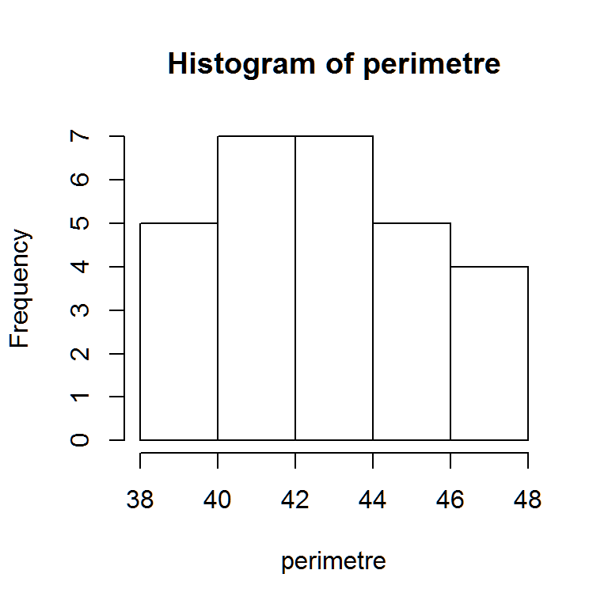

```r
  hist(perimetre)
```

Diagrama de caixes amb la funció `boxplot()`:

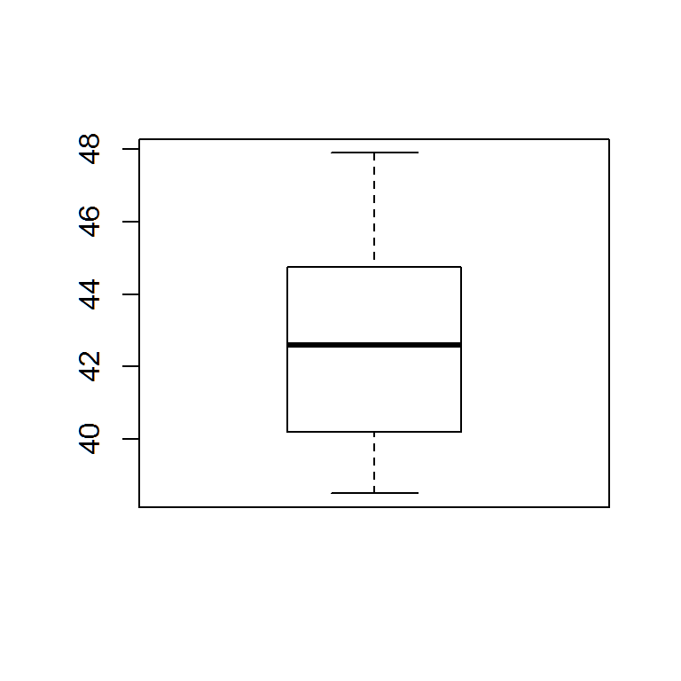

```r
  boxplot(perimetre)
```

# Exemple 2: Anàlisi descriptiva d’una variable categòrica

Les dades següents corresponen a les respostes de 15 pacients als quals els hi van demanar que qualifiquessin la seva percepció de dolor deprés de ser operats en una escala ordinal de 4 nivells:

- 0 -> “Sense dolor”
- 1 -> “Lleu”
- 2 -> “Moderat”
- 3 -> “Intens”

Introduir les dades:

```r
  dolor <- c(1, 0, 0, 0, 2, 0, 1, 3, 2, 1, 0, 2, 1, 0, 1)
```

Fes un resum numèric de la variable `dolor` amb la funció `summary()`

```r
summary(dolor)
```

```
##    Min. 1st Qu.  Median    Mean 3rd Qu.    Max.
##  0.0000  0.0000  1.0000  0.9333  1.5000  3.0000
```

El programa R està considerant que la variable `dolor` és numèrica i per això l’ha resumit amb els resums numèrics habituals: mínim, màxim, mitjana, quartils. Però aquests resums no són adeqüats per una variable categòrica.

Amb la funció `factor()` podem especificar els valors (“levels”) i el nom de les categories (“labels”) de la variable `dolor` i guardar la nova variable amb el nom `dolor2`:

```r
  dolor2 <- factor(dolor, levels = c(0, 1, 2, 3), labels = c("sense dolor", "lleu", "moderat", "intens"))
```

A partir d’ara sempre que volguem analitzar la variable `dolor` utilitzarem la nova variable `dolor2`.

**Taula de freqüències absolutes** amb la funció `table()`:

```r
  table(dolor2)
```

```
## dolor2
## sense dolor        lleu     moderat      intens
##           6           5           3           1
```

**Taula de freqüències relatives** amb la funció `prop.table(table())`:

```r
    prop.table(table(dolor2))
```

```
## dolor2
## sense dolor        lleu     moderat      intens
##  0.40000000  0.33333333  0.20000000  0.06666667
```

**Diagrama de barres** amb la funció `barplot(table())`:

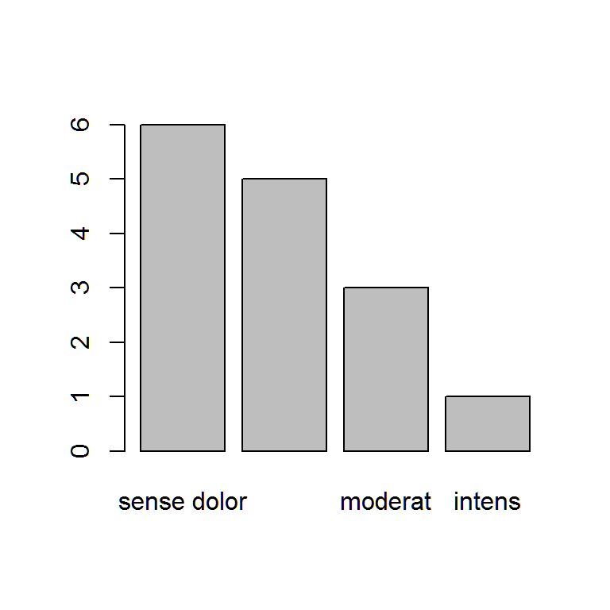

```r
    barplot(table(dolor2))
```

**Diagrama de pastís** amb la funció `pie(table())`:

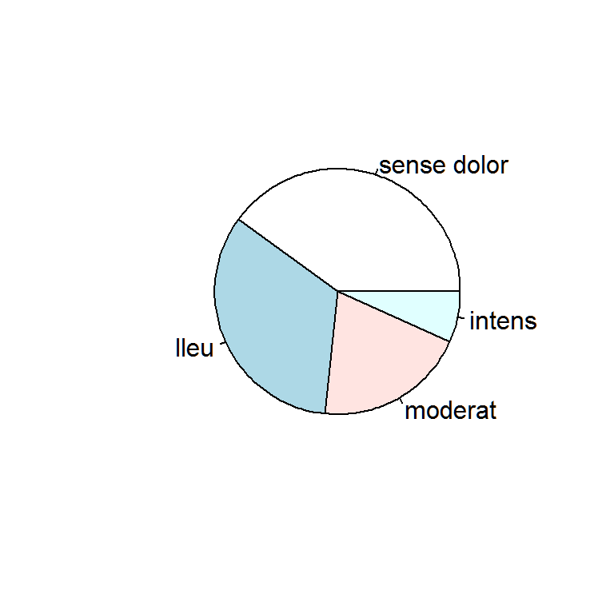

```r
    pie(table(dolor2))
```

# Exemple 3: Com carregar dades d’un fitxer?

Ens han passat informació sobre diferents individus en dos fitxers, un en format text i l’altre en format csv (comma separated value). Ara, enlloc d’introduir manualment les dades , els carreguem directament. Les fitxers son: fitxer1.txt i fitxer2.csv

NOTA: per poder carregar correctament les dades cal que els documents es trobin a la carpeta que hem especificat com a directori de treball o bé introduir l’adreça completa d’on es troben:

Especificar directori de treball amb la funció `setwd()`. Substituïu els asteriscs per la ruta al vostre directori de treball, amb el símbol / entre les diferents carpetes:

```r
setwd("*********")
```

Carregar les dades del fitxer1.txt amb la funció `read.table()` i guardar-les en una taula (*dataframe*) anomenat data1:

```r
data1 <- read.table("fitxer1.txt", header=T)
```

Mireu si heu carregat bé les dades. La funció `head()` us mostra les primeres línees:

```r
head(data1)
```

```
##      Nom      Id edat sexe
## 1   Joan 3347.12   24    H
## 2  Marta 1236.25   21    D
## 3 Carles 1703.05   24    H
## 4  Maria 3526.78   22    D
## 5  Laura 1235.24   22    D
```

Carregar les dades del fitxer2.csv amb la funció `read.csv()` i guardar-les en una taula (*dataframe*) anomenat data2:

```r
data2 <- read.csv("fitxer2.csv", header=T)
```

Mireu si heu carregat bé les dades amb la funció `head()` que us mostra les primeres línees:

```r
head(data2)
```

```
##   id   Height Group
## 1  1 169.3523     A
## 2  2 179.4973     B
## 3  3 188.4701     B
## 4  4 177.1345     C
## 5  5 190.4671     C
## 6  6 176.6555     C
```

Calculem el nombre de files de la taula data2 amb la funció `nrow()`:

```r
nrow(data2)
```

```
## [1] 18
```

Calculem el nombre de columnes de la taula data2 amb la funció `ncol()`:

```r
ncol(data2)
```

```
## [1] 3
```

Quins són els noms de les variables de la taula data2? Funció `colnames()`

```r
colnames(data2)
```

```
## [1] "id"     "Height" "Group"
```

Quin és el valor de la fila 3 i columna 2 de la taula data2?

```r
data2[3,2]  # s'especifica entre cortxets la fila i la columna, separats per coma
```

```
## [1] 188.4701
```

Quins són tots els valors del individu (fila) 3 de la taula data2?

```r
data2[3,]  # s'especifica la fila 3 però no s'especifica cap columna i així ens les mostra totes
```

```
##   id   Height Group
## 3  3 188.4701     B
```

Quines són les alçades (Height) dels individus de la taula data2?

```r
data2$Height  # cal especificar el nom de la taula i el nom de la variable separats per $
```

```
##  [1] 169.3523 179.4973 188.4701 177.1345 190.4671 176.6555 196.5342
##  [8] 183.5473 170.9949 179.6652 170.8586 177.2399 176.8214 197.3701
## [15] 189.7652 175.7714 168.8771 194.5206
```

Quines són les alçades (Height) dels primers 6 individus de la taula data2?

```r
data2$Height[1:6]  # cal especificar entre cortxets que només ens mostri els primers 6 valors de la variable
```

```
## [1] 169.3523 179.4973 188.4701 177.1345 190.4671 176.6555
```

Quants individus de la taula data2 tenen una alçada superior a 170?

```r
sum(data2$Height>170)
```

```
## [1] 16
```

# Pràctica 1: Optimització de producció in vivo d’anticossos monoclonals

- Procés que provoca la secretació en ratolins d’un fluid (ascites) que té un alt contingut d’anticossos.
- Algunes línies cel-lulars no tenen un bon creixement en animals immunocompetents i per això els animals es sotmeten a un tractament inicial de radiació que produeix una immunosupressió parcial.
- S’injecta un oli (Pristane) per aconseguir immunosupressió addicional.
- En alguns casos es torna a injectar una segona dosi de Pristane just abans de la inoculació de les cèl-lules secretores d’anticossos.
- Inoculació de les cèl-lules secretores d’anticossos cultivades prèviament in vitro.
- Els factors que poden afectar la producció d’anticossos són:
  - La dosi de radiació immunosupressiva
  - La quantitat d’oli injectat
  - El temps entre la injecció i la inoculació de les cèl-lules
  - La realització o no d’una segona injecció de Pristane
  - El nombre de cèl-lules inoculades
  - La fase de creixement del cultiu
- Experiment de laboratori: realització del procés de producció d’anticossos sota diferents situacions experimentals (diferents nivells dels factors).

## Dades

El fitxer de dades *Practica1_dades.txt* conté vuit variables:

- `lab`: indicador del laboratori (de 1 a 5)
- `tipus`: tipus de ratolí (1=normal, 2=mutat, 3=knock-out)
- `radiacio`: Radiació inicial, en Hz
- `q_oli`: quantitat d’oli injectat (en ml.)
- `temps`: temps des de la injecció d’oli fins a la inoculació (en minuts)
- `oli_2`: indicador de la segona injecció ( 0 = “NO”, 1 = “SI”)
- `n_cel`: nombre de cèl-lules inoculades (en milions)
- `volum`: volum d’ascites segregat (en ml.)

## Qüestions

**1.** Baixa el fitxer *Practica1_dades.txt* a la teva carpeta de treball.

**2.** Crea un nou script i al final de la sessió guarda’l amb el nom *pract1_elteucognom.R*.

**3.** Especifica el teu directori de treball (on has guardat el fitxer de dades).

**4.** Carrega les dades i guarda-les amb el nom `ratolins`. En aquest cas, quina instrucció has de fer servir per carregar les dades: `read.table()` o `read.csv()`?

**5.** Mira les primeres files de la taula de dades que has carregat amb la funció `head()`.

**6.** Calcula els estadístics descriptius (mínim, màxim, mitjana, mediana, desviació típica i variància) de la variable `volum`. Recorda que has d’especificar la variable així: `ratolins$volum` (nom de la taula de dades $ nom de la variable).

**7.** Representa gràficament la variable `volum` Quin gràfic és més apropiat en aquest cas, un diagrama de barres o un histograma?

**8.** Modifica el gràfic anterior de manera que les dades estiguin dividides en 10 intervals. Si no saps com fer-ho utilitza la comanda `help()` o `?`.

**9.** Fes un resum numèric de la variable `tipus`. Tenen sentit els valors resum que has obtingut?

**10.** Especifica la variable `tipus` com a variable categòrica especificant les categories (1=normal, 2=mutat, 3=knock-out) amb la funció `factor()`. Fes que la nova variable es digui `tipus.cat`. Per tal que la nova variable es guardi en la taula de dades `ratolins` li has d’assignar el nom `ratolins$tipus.cat`.

**11.** Calcula el resum numèric de la nova variable `tipus.cat`. Què et proporciona aquest resum numèric? Ara té sentit aquest resum numèric?

**12.** Dóna la taula de freqüències relatives de la variable `tipus.cat`.

**13.** Representa gràficament la variable `tipus.cat`. Quin gràfic és més apropiat en aquest cas, un diagrama de barres o un histograma?

**14.** Canvia el color del gràfic. Si no saps com fer-ho utilitza la comanda `help()` o `?`.

**15.** Especifica la variable `oli_2` com a categòrica amb les etiquetes: 0 = NO, 1 = SI.

**16.** Representa gràficament la variable `oli_2`.

**17.** Selecciona els ratolins que han tingut una radiacció superior o igual a 235 i guarda totes les seves dades en una taula anomenada `ratolins2`:

```r
ratolins2 <- ratolins[ratolins$radiacio>=235,]
```

**18.** Fes un gràfic de la variable `volum` dels ratolins amb una radiació superior o igual a 235 (és a dir, dels ratolins de la taula `ratolins2`).

**19.** Fes un resum numèric de la variable `volum` dels ratolins amb una radiació superior o igual a 235 (és a dir, dels ratolins de la taula `ratolins2`).